# A comparison of the LS and HER models for the 2018 Sitka herring forecast

Jane Sullivan

August 2018

# Background

The purpose of this document is to compare 2018 forecasts between two age-structured assessment (ASA) models, the current management least-squares (LS) model developed by Pete Hulson (Hulson et al. DRAFT 2014), and an alternative model (HER) developed by Steve Martell (Martell 2016). We applied the comparison of these models to the 1980-2017 time series of Sitka Pacific herring data for the 2018 forecast.

In order to compare the models, we applied the parameterization from the best-fitting 2018 forecast LS model to HER. This parameterization includes: three time blocks for natural mortality (1980-1998, 1999-2014, 2015-2017), two time blocks for maturity (1980-2014, 2015-2017), and one time block for selectivity (1980-2017). It is important to keep this in mind when comparing the fits of the two models - what might be the best-fitting parameterization in LS, may not be the best-fitting parameterization for HER.

HER has built-in options to condition on effort instead of catch (it is conditioned on catch in this document) and can have alternative parameterizations of time-varying parameters (e.g. cubic spline for natural mortality).

Objectives and deliverables for this project included:

1. Update the HER report file
2. Generate graphics and tables
3. Conduct retrospective analysis
4. Add feature to examine likelihood profiles
5. Estimate variance using MCMC on quantities of interest
6. Run simulation test
7. Goal of a side-by-side comparison of 2018 forecast (2017 data)
   - Document any differences in underlying model structure or assumptions
   - Compare quantities of interest and explore differences

In addition to the comparison figures contained in this document, there are LS- and HER-specific figures in HER/figs/LS and HER/figs/HER.

# Differences between LS and HER

This list is a work in progress, and I hope to develop it through the review process and as we continue to explore HER.

1. The structure and estimation of natural mortality is very different between models: LS did not have any prior on M, only bounded from 0.001 to 1. LS estimates independent M for each time block. HER estimtes log mean M and then estimates time varying (block or cubic spline) deviations for each block. The result is that natural mortality in HER is not allowed to very much over time (it is functionally constant), which appears to be causing residual patterns in biomass over time.
2. Rounding issues in the input data. The LS dat file had extremely high precision, which we changed in HER.
3. HER does not use objective function weights. In particular, the LS is weighted by hand, with zero weight given to the stock recruitment (S-R) relationship. HER apparently gives the S-R relationship more weight.
4. The assumptions related to maturity catch is different in HER and LS: HER applies the maturity curve to catch numbers-at-age, such that spawning_Nij = maturity_ij $/times$ (total_Nij – catch_Nij), and LS assumes catch to be 100% mature spawning_Nij = (maturity_ij $/times$ total_Nij) – catch_Nij. This is a subtle difference (one parenthesis) between HER and LS that results in a lack of convergence (Hessian does not appear to be positive definite) when I recode HER to match the LS assumption. I’ve been in touch with Sherri on this issue, providing output of mature and catch numbers-at-age. None of the values are negative. When I run HER with the assumption that all catch is mature, ADMB produces a report file. I generated a file displaying all the figures from this report file, and there are no glaring differences except that the estimate of survival went from ~0.5 to 0.6. One potential path forward is to code the LS model like the HER model to see if it runs and substantially changes the results.
5. Phasing different for leading parameters. This should be explored and documented more thoroughly in future developments.
6. Parameters bounds for leading parameters. This should be explored and documented more thoroughly in future developments.
7. Selectivity is estimated differently in HER than it is in LS. To make sure selectivity is differentiable in HER, it was scaled to have a mean of 1 across all ages. This was done in log space by substracting the mean from the vector of age-specific selectivities (Martell 2016 p. 11). We have scaled our results here for easier comparison (see section on Time-varying parameters).

# HER model convergence

The HER model estimated 59 and had a negative log likelihood of -1,173.181.

The max gradient for HER was 8.14535e-05. Values < 0.001 generally indicate convergence. Values > 0.001 likely means that the model did not converge and that 1) you may be at a local minima and new initial values should be tried to see if you end up in the same place, 2) your likelihood surface is not well defined and you may have a model structural problem (high parameter correlation could be contributing to this problem), or c) you legitimately have multiple solutions that satisfy your objective function.

# Forecast values

The breakdown of forecasted mature biomass-at-age was similar between LS and HER, with the dominant age classes being age-4 and age-6 in both models (Table 1).

[output not shown]

Table 1. Summary table for the LS and HER model forecasts, including the forecasted mature biomass-at-age (tons), weight-at-age used for each forecast (should be the same between models), and the estimated proportion of the total numbers-at-age that were mature.

# Population trends

## Mature biomass

The HER and LS model track survey estimates of mature biomass reasonably well in terms of magnitude and trend (Figure 1), although the LS model fits considerably better. Notably the HER 95% credibility interval does not contain the survey estimates, except during periods of intermediate biomass. This may be due to the difference in weight given to the stock-recruitment relationship between the two models (less weight in LS, more in HER), or it could be to the inability of HER to vary natural mortality (see sections on Time-varying parameters and Differences between LS and HER).

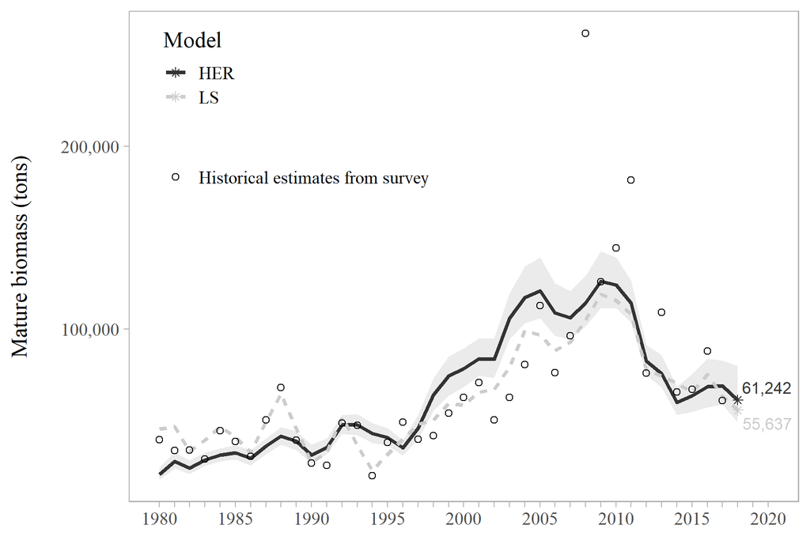

Although it is not a comparison of HER and LS, we revamped the figure code for the LS comparison of past assessment models’ estimates and forecasts of mature biomass (Figure 3).

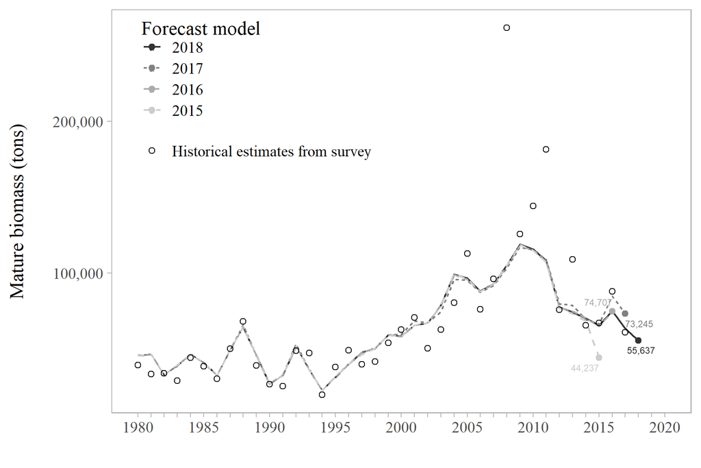

Similarly, we also revamped the figure code for comparing catch/GHL and spawing biomass for the LS model (Figure 4)

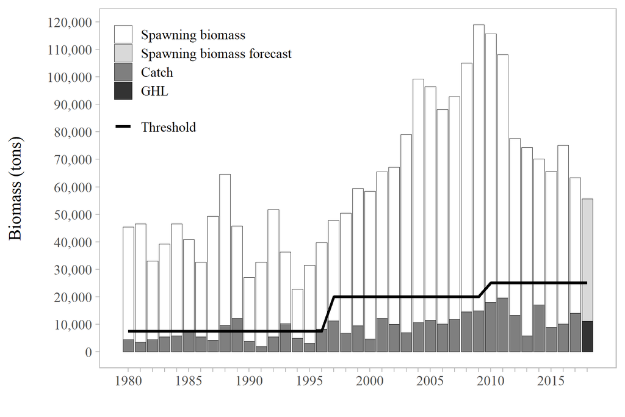

Figure 4. Stacked bar graph of spawning biomass (white), spawning biomass forecast (light grey), catch (dark grey), and the GHL (black). The threshold (black line) is the biomass level defined in regulation below which no fishery occurs. The harvest (or GHL) plus the spawning biomass equals the mature biomass. If there is no catch (or GHL), the spawning biomass (or spawning biomass forecast) equals the mature biomass (or mature biomass forecast).

## Egg deposition

The HER and LS model track the historical survey estimates of egg deposition reasonably well in terms of magnitude and trend (Figure 5), although the LS model fits considerably better. The HER model shows a strong residual pattern, starting with all positive residuals and switching to all negative residuals (Figure 6), which in demonstrative of poor fit.

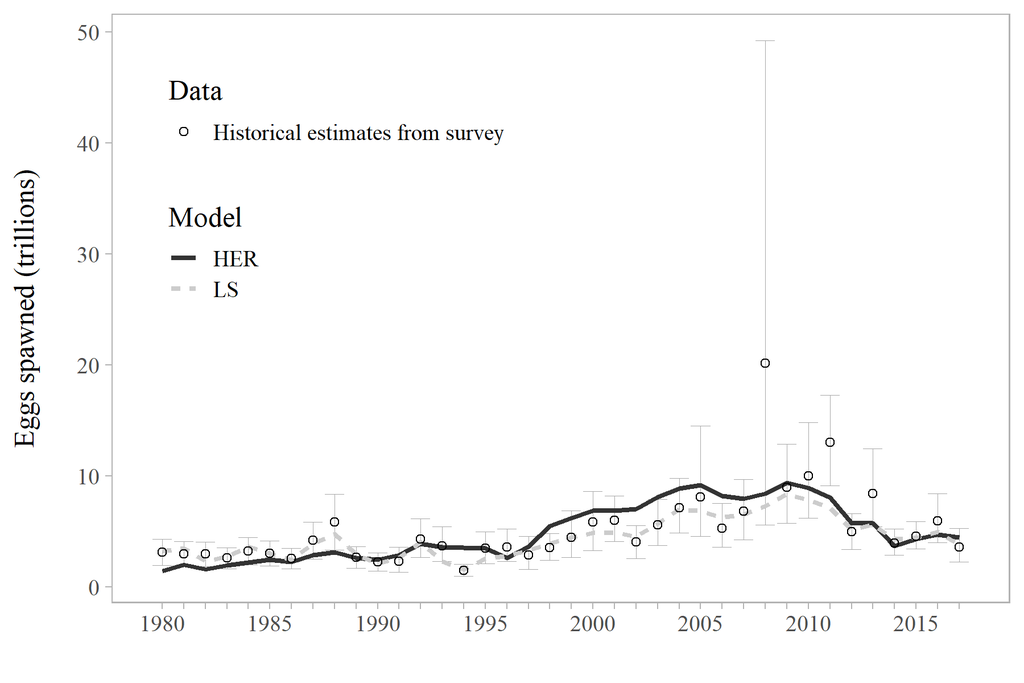

Figure 5. Model-estimated egg deposition (number of eggs spawned in trillions) in HER (black solid line) and LS (grey dashed line) compared to historical estimates from the survey (open circles). The grey bars show the boostrap-estimated 95% confidence interval for the survey estimates.

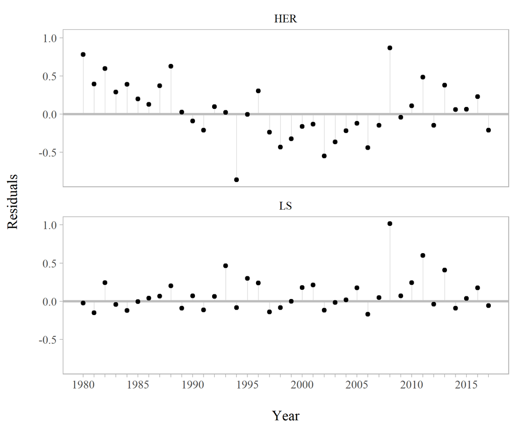

Figure 6. A comparison of HER (top panel) and LS (bottom panel) egg deposition residuals calculated as the difference between survey and model-estimated egg deposition on the logarithmic scale.

# Age Compositions

## Composition data

New figures for commercial catch and cast net survey age compositions for Sitka have been created for this project (Figure 7).

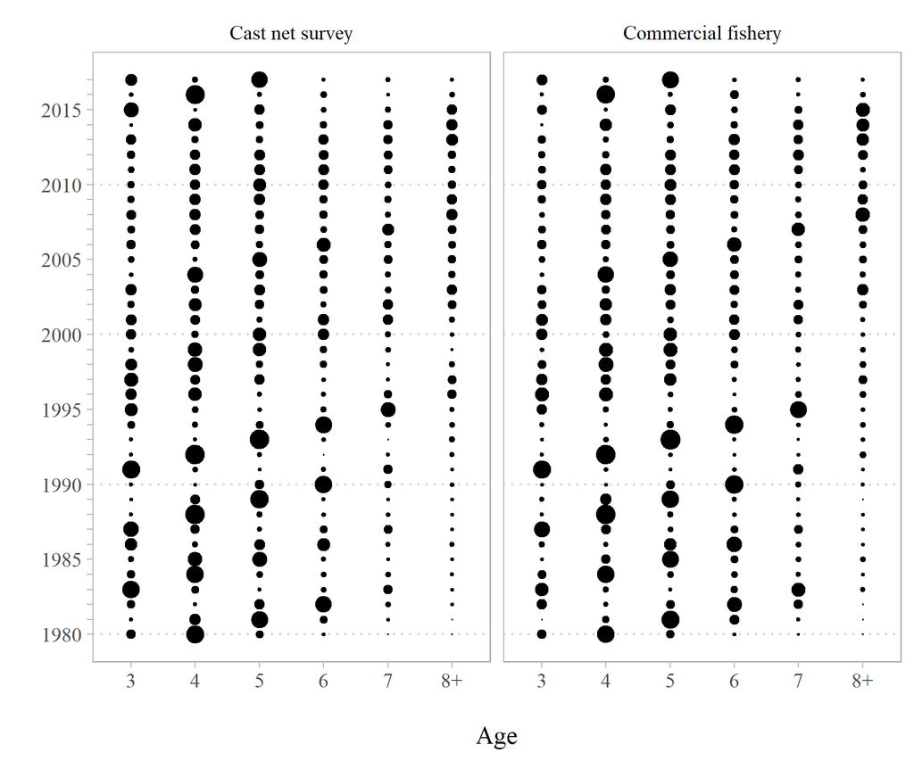

Figure 7. Cast net survey (left panel) and commercial seine fishery (right panel) age compositions by year.

## Residuals

The HER model shows a moderate residual pattern in both age composition data sources in ages-7 and 8+, switching from predominately negative residuals around 1998 (Figure 8). The LS model does not show this strong of pattern (Figure 9).

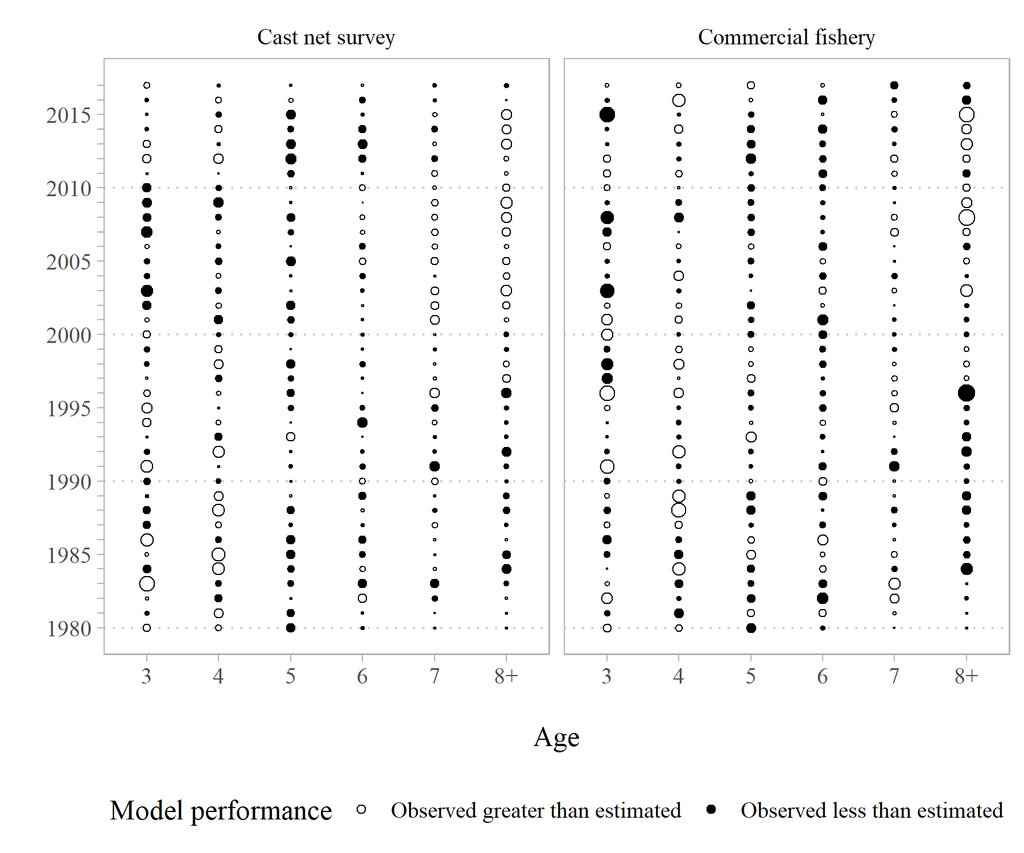

Figure 8. Cast net survey (left panel) and commercial seine fishery (right panel) age composition residuals for the HER model, calculated as the difference between observed proportion-at-age and estimated proportion-at-age.. A positive residual (white) indicates that the observed value is greater than the model estimate, and negative (black) means the opposite. The size of the circle is relative to the size of the residual.

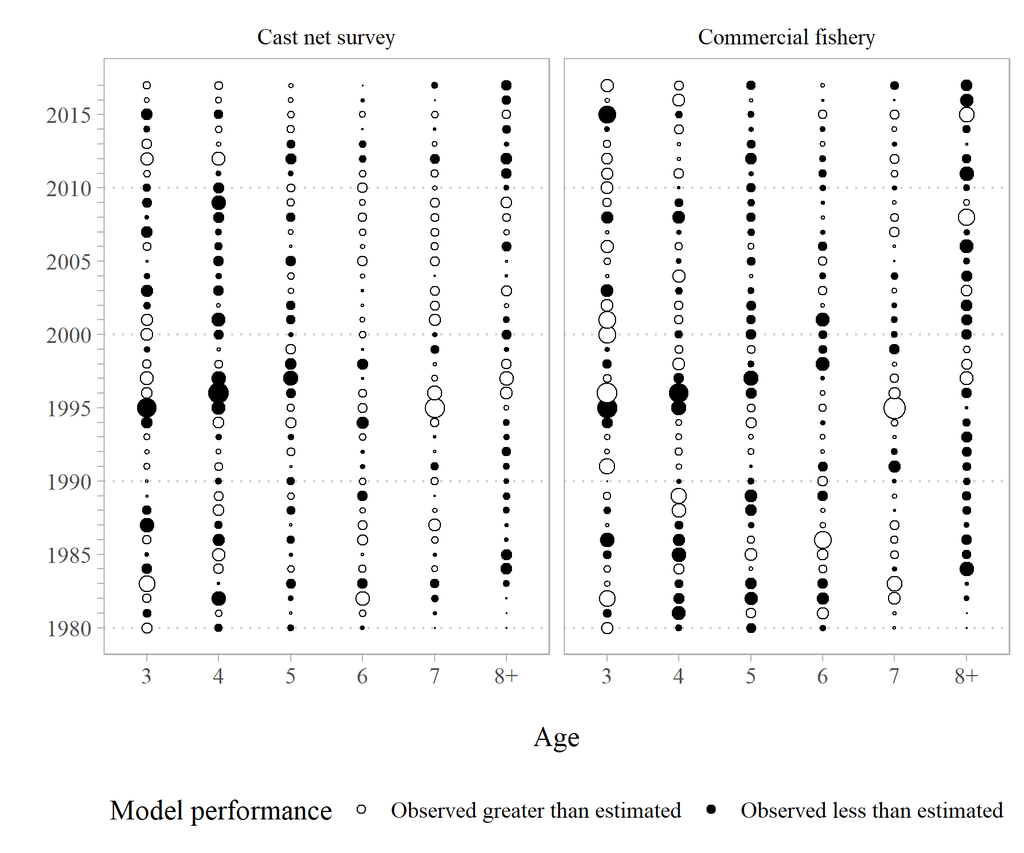

Figure 9. Cast net survey (left panel) and commercial seine fishery (right panel) age composition residuals for the LS model, calculated as the difference between observed proportion-at-age and estimated proportion-at-age. A positive residual (white) indicates that the observed value is greater than the model estimate, and negative (black) means the opposite. The size of the circle is relative to the size of the residual.

## Comparison of fits

Despite the residual pattern in HER, both models fit the catch (Figure 10) and cast net (Figure 11) age composition data well.

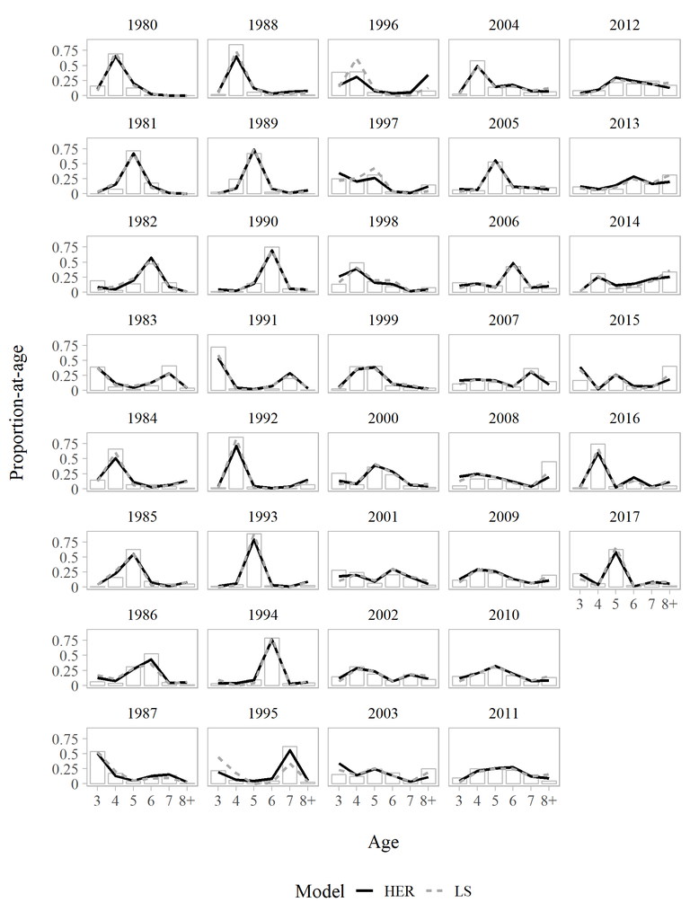

Figure 10. Proportion-at-age observed in the commercial seine fishery (white bars) compared to model-estimated proportion-at-age in HER (black solid lines) and LS (grey dashed lines).

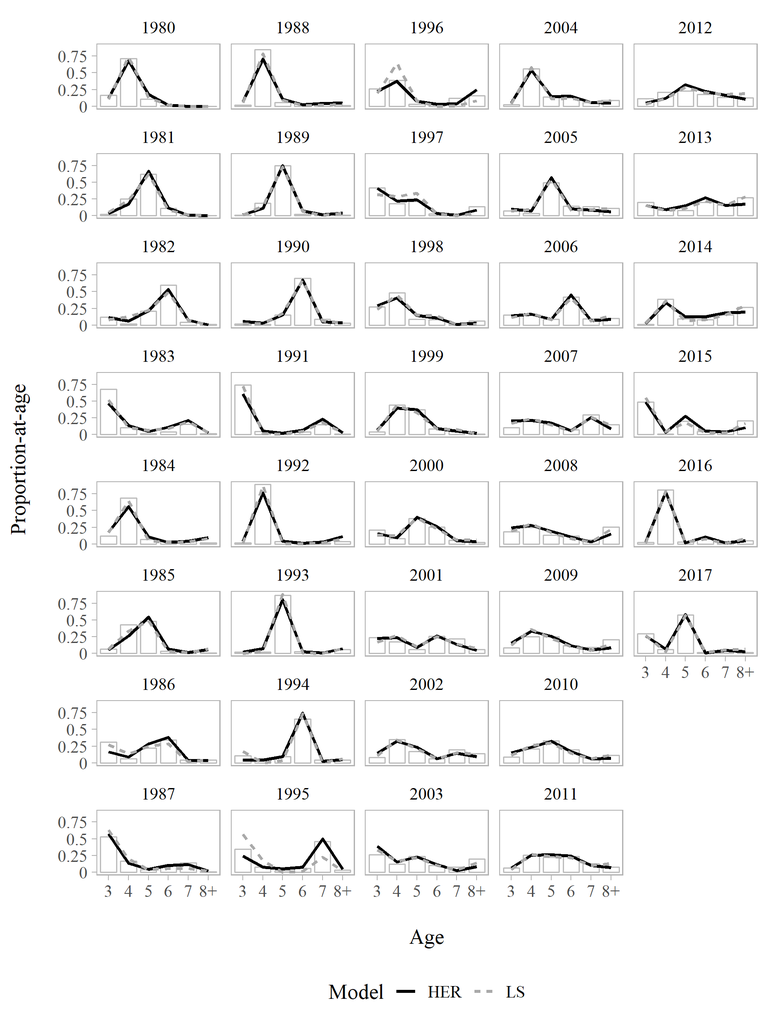

Figure 11. Proportion-at-age observed in the cast net survey (white bars) compared to model-estimated proportion-at-age in HER (black solid lines) and LS (grey dashed lines).

# Recruitment

Although the trends in recruitment are similar between HER and LS, the magntitude is quite different (Figure 12 and Figure 13). We attribute this difference to the manual weighting of the LS stock-recruitment relationship to zero, whereas HER appears to put a stronger weighting on this relationship. Neither model shows a concerning residual trend (Figure 14).

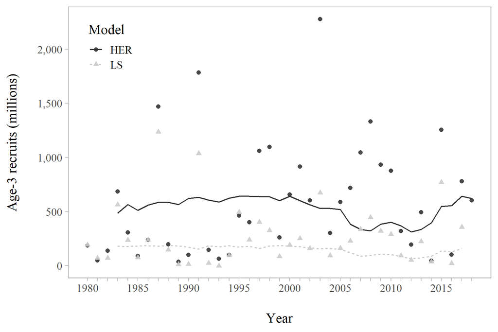

Figure 12. A comparison of estimated age-3 recruits in millions from the Ricker model (lines) and age-structured model (points) in HER (black solid line and circles) and LS (grey dashed line and triangles).

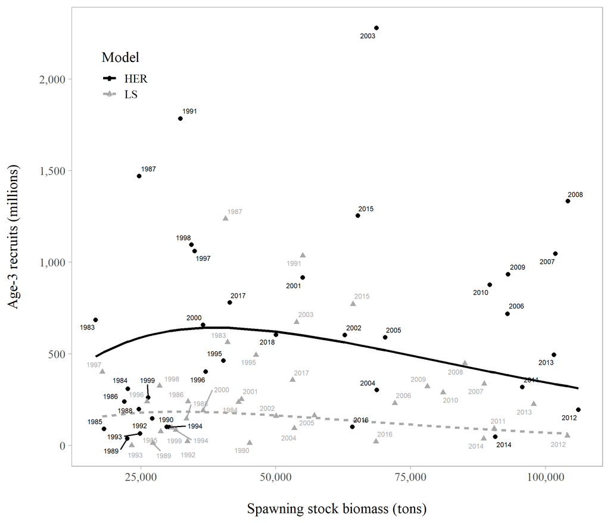

Figure 13. A comparison of annual estimates of age-3 recruits (millions) versus spawning stock biomass (tons) in the age-structured model (points) and Ricker model (lines) between HER (black circles and curve) and LS (grey triangles and dashed curve).

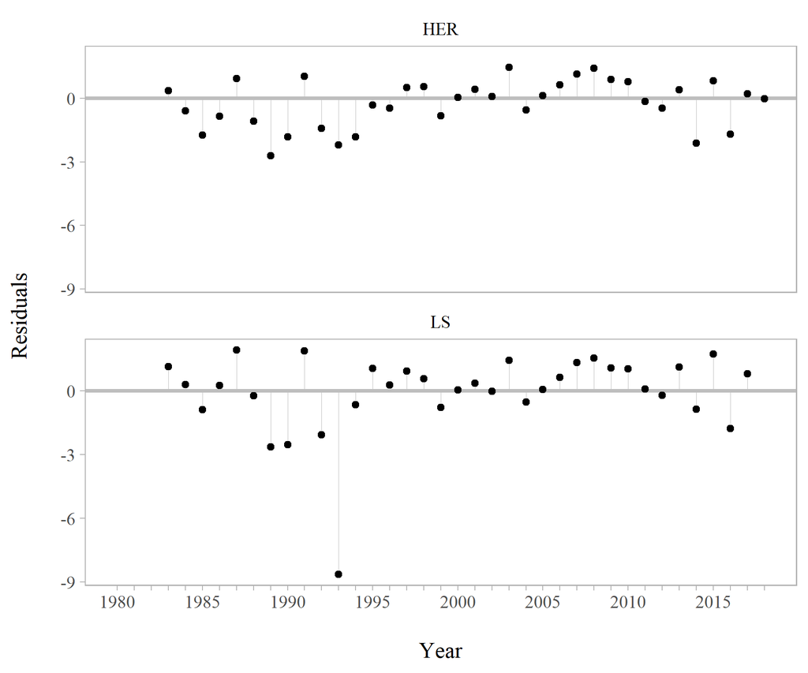

Figure 14. A comparison of HER (top panel) and LS (bottom panel) recruitment residuals calculated as the difference between age-3 recruits in the age-structured model and Ricker model on the logarithmic scale.

## Next steps

Sara would prefer the points in Figure 12 as side-by-side bars instead of points, and to show the credibility interval around the ASA-estimated points in Figure 13.

# Time-varying parameters

Time varying parameters were quite different between LS and HER. Owing to the way natural mortality $M$ is estimating in HER (see #1 under section Differences between LS and HER), survival (-exp($M$)) appears constant across time blocks in HER. Survival is very similar in HER and LS between 1980 and 1998 (~0.57), but survival increases dramatically in LS during the 1999-2014 time block corresponding to the population increase during that period, and has dropped off slightly since 2015 (Figure 15). The inability for the HER model to vary $M$ likely contributes to the model’s poor fit and residual patterns in mature biomass (Figure 1), egg deposition (Figure 6), and age compositions (Figure 8).

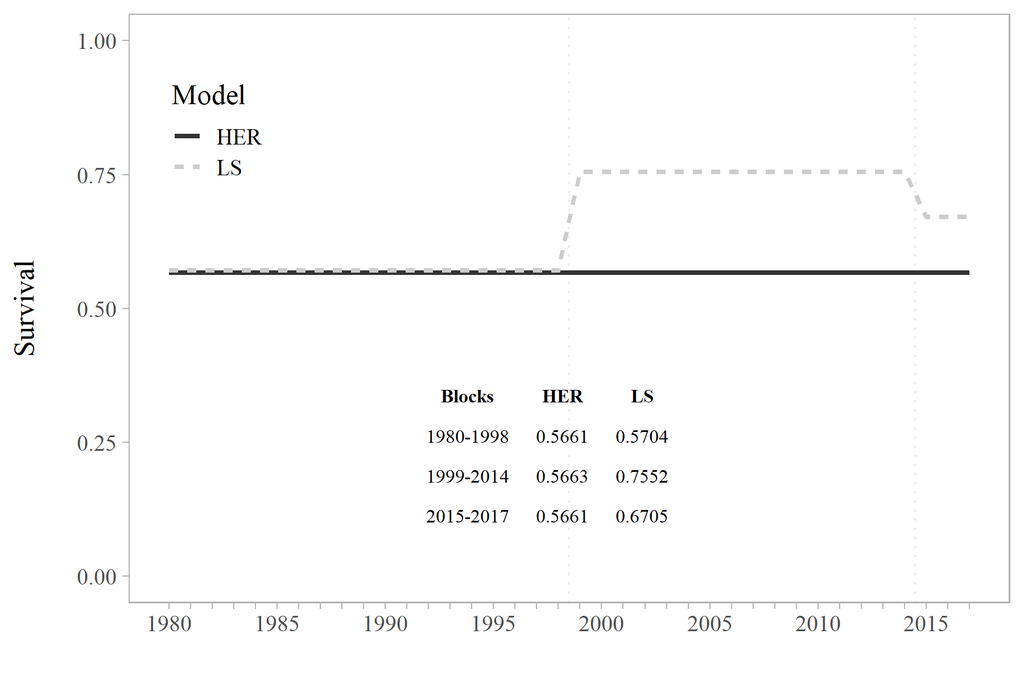

Figure 15. A comparison of HER (black solid line) and LS (grey dashed line) model estimates of survival by time block.

The LS model estimates of matuirty-at-age in both time block suggest herring mature at a much younger age than what is predicted in HER (Figure 16). Similarly, the LS model predicts that a greater proportion-at-age selects to the gear than HER (Figure 16). In HER, selectivity was scaled to have a mean of 1 across all ages in log space by substracting the mean from the vector of age-specific selectivities. We normalized it betweeb 0 and 1 in order to directly compare the estimated selectivity-at-age between HER and LS by dividing selectivity-at-age by the maximum selectivity.

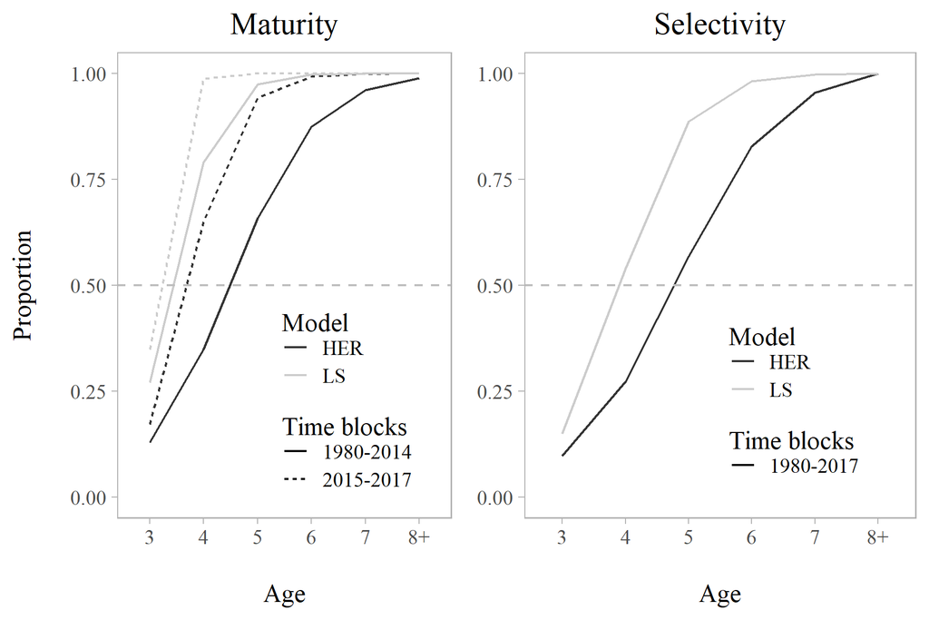

Figure 16. A comparison of HER (black) and LS (grey) model estimates of maturity (left panel) and selectivity (right panel) by time block.

# Weight-at-age

Fish and Game uses weight-at-age from the fishery for both fishery and spawner weight-at-age in both LS and HER, because there are too many spawned out fish collected in cast net that may bias samples. The only exception is 1997, when cast net samples were used for spawner weight-at-age because the weight-at-age in the fishery was deemed to be too high.

Weight-at-age has been quite variable in the Sitka herring stock, as evidenced by cohort-specific trends (Figure 17) and trends by sampling year (Figure 18).

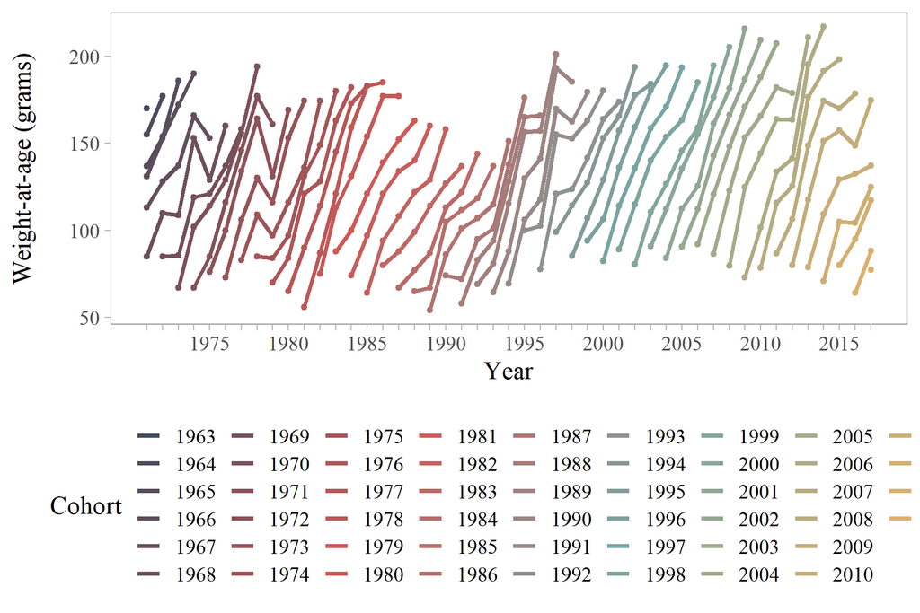

Figure 17. Commercial catch weight-at-age (grams) by cohort.

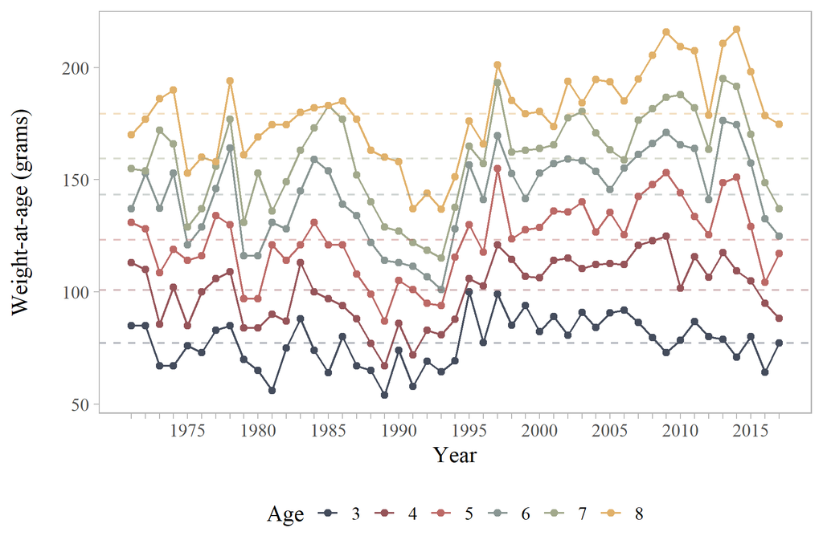

Figure 18. Weight-at-age (grams) by sampling year. Mean weight by age class over time is shown in the dashed lines.

## Next steps

Remove age-8 from these figures because it’s the plus group.

# Variance estimate using MCMC

Estimating variance in ADMB can be split into a series of smaller objectives: 1) determining quantities of interest, 2) generating output files for posterior samples on quantities, 3) writing R code for implementing MCMC in ADMB, including determining number of iterations and proper thinning, and 4) writing R code for testing convergence diagnostics, variance estimation, and visualization of results.

With the help of Sherri and Sara, we determined quantities of interest for variance to be: - Mature biomass (pre-fishery) - Spawning stock biomass (post-fishery) - Forecast mature biomass - Natural mortality/survival - Recruitment *Needs to be updated, see Next steps* - Maturity - Selectivity - Catch (I added this, but it only works when conditioning on effort - conditioning on catch assumes zero variance) - Egg deposition

The HER.tpl file now contains code to sample the posterior distributions for all of these quantities. One roadblock to this was the fact that the population dynamics model for HER had several differences that made it challenging to derive specific quantities of interest. These have by and large been corrected, and this is no longer an issue. The notable exception is that the assumptions about catch being mature are different in the least-squares (LS) and HER models. I’ve been in contact with S. Dressel and S. Miller about this via email since 2018-07-30.

The her.R script contains a few functions to tidy and visualize output from the posterior samples of quantities of interest. I also wrote sample/example code to visual confidence intervals (e.g. Figure 19), examine diagnostic caterpillar plots for both derived quantities (e.g. Figure 20) and age-based or time-varying quantities (e.g. Figure 21), and look at the posterior densities (e.g. Figure 22 and Figure 23). As indicated by the diagnostic caterpillar plots, the MCMC chain was not run for long enough to ensure convergence or full mixing.

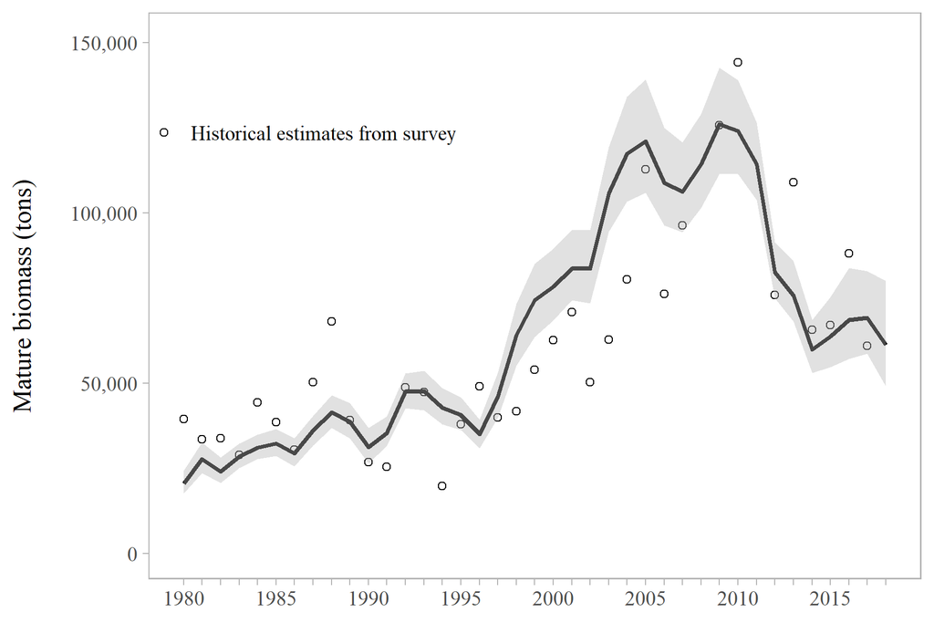

Figure 19. An example of visualizing the 95% credibility intervals for mature biomass.

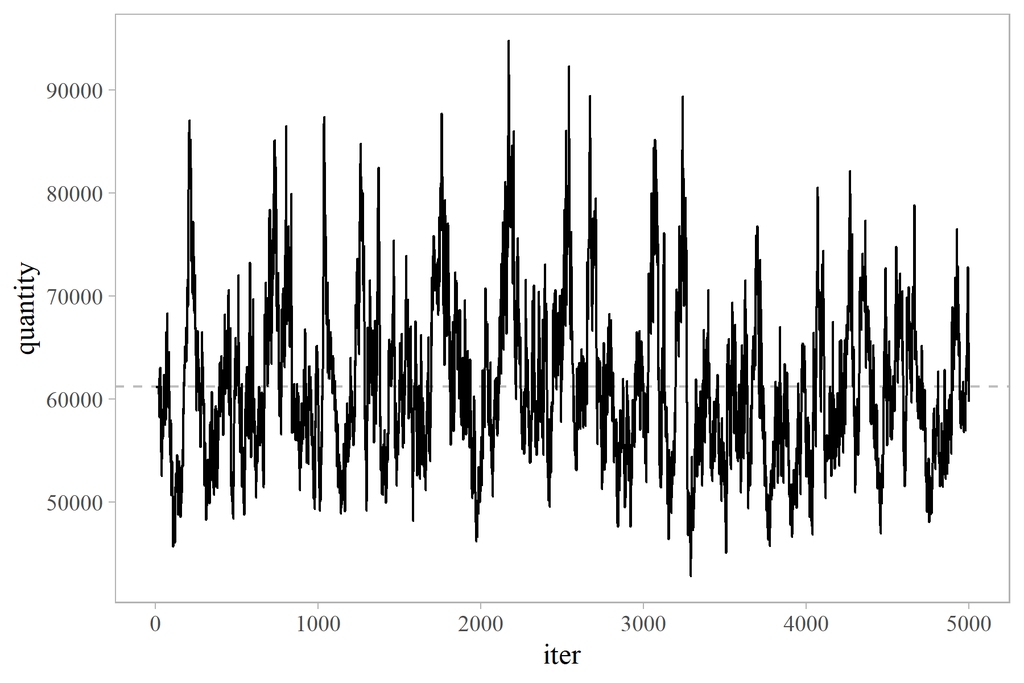

Figure 20. An example of a diagnostic caterpillar plot for forecasted mature biomass.

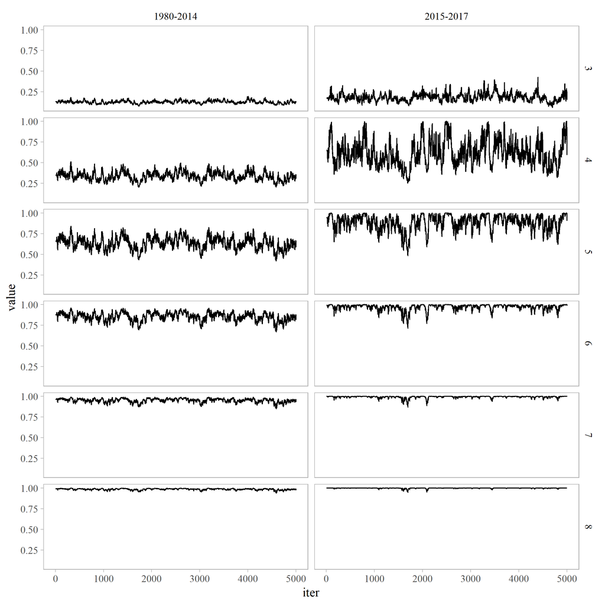

Figure 21. An example of a diagnostic caterpillar plot for an age-structure and time-varying parameter.

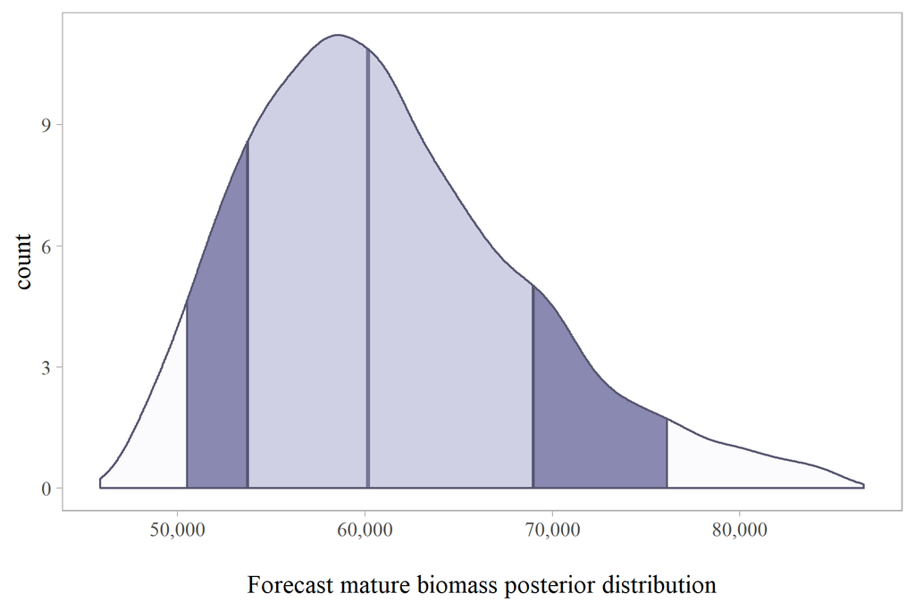

Figure 22. The full posterior densities of mature biomass, including the median (line) and 50% (lighter shading) and 95% percentiles (darker shading).

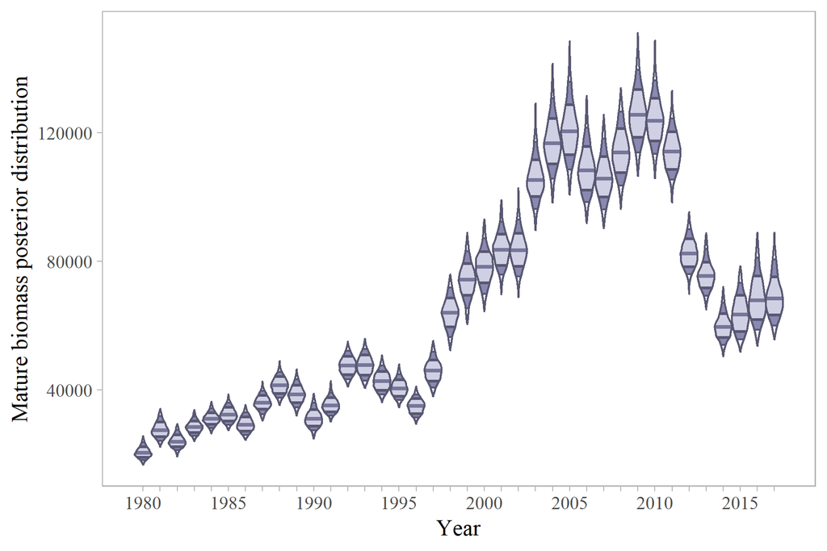

Figure 23. The full posterior densities of mature biomass, including the median (line) and 50% (lighter shading) and 95% percentiles (darker shading).

We’ve identified the ‘adnuts’ package, written by Cole Monnahan, a past UW PhD student, as a viable option for running HER in a Bayesian framework. The methods and motivation for the ‘adnuts’ package was published this year in PlosOne and was coauthored by the lead developer of TMB, Kasper Kristensen (Monnahan and Kristensen 2018). The workhorse algorithm NUTS (no U-turn sampler) was originally developed by Hoffman and Gelman (2014).

The ‘adnuts’ package came out of Monnahan’s dissertation, which focused on advancing Bayesian methods in fisheries science (Monnahan 2017). Traditional MCMC methods when applied to complicated models (i.e., age- and length-structured stock assessments or hierarchical models) are slow and inefficient. During the heyday of ADMB, most assessments relied on frequentist methods for inference. Consequently ADMB’s existing infrastructure for implementing Bayesian methods is pretty rudimentary. In Monnahan’s second chapter, he tested the existing Bayesian algorithms compared to NUTS for 6 stock assessment models and found NUTS to be faster (10-1000x) and more reliable at fully exploring posterior parameter space.

Benefits of the ‘adnuts’ package include: 1) the framework, functions, and capabilities are similar to what is contemporaneously used for TMB and STAN models; and 2) early explorations suggest that it greatly increases our ability to do MCMC sampling via multiple choices for algorithms, the ability to execute multiple chains (oddly not a built-in feature in ADMB), built-in diagnostic features, and the choice to change starting values (ADMB defaults to MLE estimates, which can be problematic if converging at a local minima). There are also other bells and whistles like the ability to run chains on multiple cores and an argument for setting time duration that will stop sampling after the set time (especially useful for model testing and running your model overnight).

## Next steps

While the posterior samples are written, more code should be developed for diagnostic plots and visualizing variance estimation.

During review, it was discussed that there were marked differences in the estimated variance of maturity and selectivity. Potential reasons for this include 1) the small time period defined for the second maturity time block, 2) the rescaling of selectivity (Jane examined this and it was not the case), 3) the model is conditioned on catch (perhaps if it was conditioned on effort selectivity would be more variable), and 4) the population dynamics equations are currently written such that catch is not assumed to be 100% mature as in the LS model (thus resulting in additional variability in maturity).

It was discussed that the variability on forecasted spawning stock biomass was very narrow. It is unclear why this is the case, but should be examined more in the future.

Sherri and Sara wanted the age-3 abundance as estimated by the ASA model, instead of recruitment as estimated by the Ricker curve, which is how the tpl is currently coded. This can be easily corrected in future developments.

Finally future development should include running the MCMC evaluation using functions from the ‘adnuts’ library, so that we can test different starting values, run the model with multiple chains, test the efficiency of the alternative NUT algorithm, and utilize the more comprehensive built-in suite of diagnostic tools. Additionally, we currently estimate variance on maturity and selelctivity-at-age (or estimated recruitment), but do not run the MCMC on the actual parameters for the logistic or Ricker curves. It would be a good next step to complete this task and explore correlations between these parameters.

# HER retrospective behavior

The corresponding code for the retrospective analysis is found in R/retrospective.R

Definitions:

*Terminal year* - the most recent year of the assessment

*Peel* - removing a year and re-running the most current assessment for that year

The figure generated for the retrospective analysis shows retrospective behavior of spawning biomass and the percent difference from the terminal year for each peel (Figure 24). These figures were modeled after figures presented at a workshop of the Alaska Groundfish Plan Teams (Clark et al 2012).

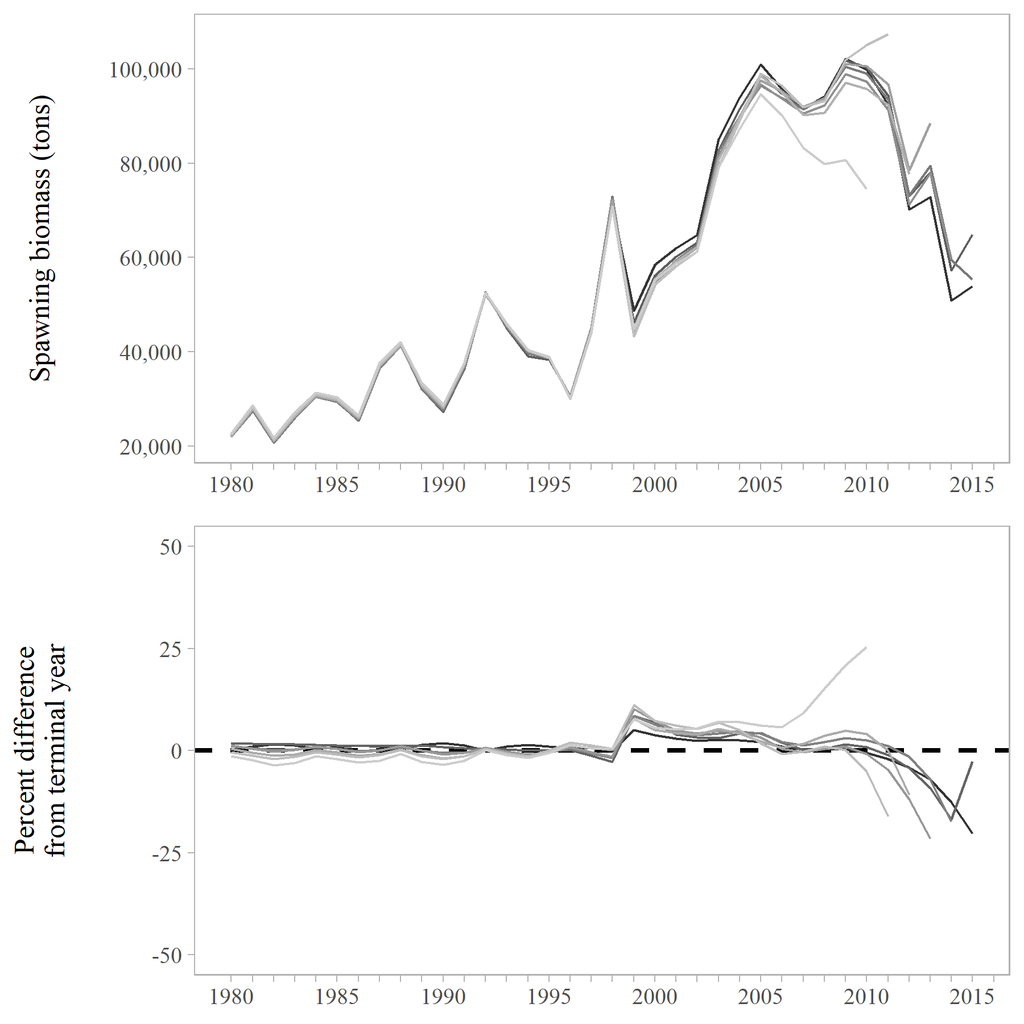

Figure 24. Retrospective analysis of HER estimates of spawning stock biomass (tons) on the top, and the percent difference of each peel from the terminal year on the bottom

Two summary statistics are calculated: the first is the Mohn’s Rho as defined by the Alaska Fisheries Science Center and Hurtado-Ferro et al. (2015), which is the difference between the estimate in a peel year and the reference estimate from the terminal year divided by the reference estimate and summed across all peels. The second statistic, the Wood’s Hole Rho, uses all estimates in the peel, not just the final estimate. LeGault et al. (2009) found no marked differences between the two rhos. These statistics are written to a file called ‘HER/retrospective_rhos.csv’. Mohn’s and Wood’s Rhos were quite small for this version of the model (0.08 and -0.005, respectively).

An excerpt from Hurtado-Ferro et al. (2015) regarding the interpretation of Mohn’s Rho: Given that the variability of Mohn’s rho depends on life history, and that the statistic appears insensitive to F, we propose the following rule of thumb when determining whether a retrospective pattern should be addressed explicitly: values of Mohn’s r higher than 0.20 or lower than 20.15 for longer-lived species (upper and lower bounds of the 90% simulation intervals for the flatfish base case), or higher than 0.30 or lower than 20.22 for shorter-lived species (upper and lower bounds of the 90% simulation intervals for the sardine base case) should be cause for concern and taken as indicators of retrospective patterns. However, Mohn’s Rho values smaller than those proposed should not be taken as confirmation that a given assessment does not present a retrospective pattern, and the choice of 90% means that a “false positive” will arise 10% of the time.

Because the version of HER presented in this document has time blocks for maturity and natural mortality starting in 2015, the current retrospective code will not run for all peels (it runs for the first 2, then stops). In order to accomodate this issue and provide an example of a working retrospective analysis for HER, I created a new branch called ‘retrospective’ in the AlaskaHerring repository, and made the following changes to the HER/sitka_2.ctl file:

Maturity blocks: 1980-1998 and 1999-2017 Natural mortality blocks: 1980-1998 and 1999-2017

## Next steps

I recommend two steps forward on the retrospective analysis for HER. The first is to modify the read_admb() function to better accomodate runs that do not converge. Currently I get an error “Error in file(con,”r“) : cannot open the connection In addition: Warning message: In file(con,”r“) : Error in file(con,”r“) : cannot open the connection. I do not fully understand this error but know it traces back to the read_fit() function that is nested inside the read_admb() function.

The second recommendation is to figure out a solution for dealing with peels that go beyond a break in a time block for a time-varying parameter. This could be something to bring up during Punt’s course, to Steve Martell, or perhaps at Groundfish Plan Team.

# HER simulation

The simulation approach used is called “self-testing,” where the same model (with known parameters) is used to generate data and then estimate parameters based on the simulated data. This approach should generate exact parameter estimates in the case where data are generated with no simulated observation errors. The step-by-step code and documentation is written in R/simulations.R. Currently it is written to condition/fit the model to the Sitka data then use these parameter values to estimate data and then re-estimate parameters. Currently the simulation self-tests perfectly, but does not include any observation or process error. This would be a future development and perhaps something to ask S. Martell about.

## Next steps

Sherri and I discussed that this as an area for considerable development and may be a potential contract with Steve Martell.

# Likelihood profiles

The motivation for examining likelihood profiles, which are the minimum negative log-likelihoods for a range of values of a single parameter, is generally two-fold: 1) calculating confidence intervals, and 2) examining properties of the likelihood surface (e.g. smoothness/steepness of the parameter space, presence of local minima, etc.). In Bayesian analyses, both of these are replaced by examining the posterior distribution.

The standard ADMB procedure for calculating likelihood profiles is proving very difficult to apply to HER. According to Ben Bolker’s chapter on likelihood, specifically pages 31-35, it’s not surprising that I’m encountering difficulty estimating likelihood profile surfaces for such a complex model. He points out that likelihood profiles are not used for variance estimation of such complex models, and that instead the second derivatives of the log-likelihood as a function of the parameters (aka the Hessian matrix) are used. From here the Hessian, the ‘negative of the expected value’ of the Hessian (the Fisher information matrix), and the ‘Fisher evaluated at the maximum likelihood estimate’ (the observed information matrix) represent the curvature of the likelihood surface along a particular axis. This will tell us everything we need to know about model fit and uncertainty. Perhaps in Andre’s course we will learn more about how to utilize the Hessian to explore parameter space, but at the moment I feel ill-equipped to venture out into the Hessian, the Fisher information, or the observed information matrix alone. I think instead that an examination of the posteriors will give us all the information we need to know.

## Next steps

The topics of exploring likelihood profiles is something Sherri would like me to pursue during Punt’s course.

# References

Clark, B., D. Hanselman, M. Sigler. 2012. Report of the retrospective analysis working group. September 2012 Plan Team Draft. https://www.afsc.noaa.gov/refm/stocks/plan_team/2012/sept/retrospective_analysis.pdf

Hoffman, M.D. and Gelman, A. 2014. The No-U-turn sampler: adaptively setting path lengths in Hamiltonian Monte Carlo. Journal of Machine Learning Research, 15(1), pp.1593-1623.

Hulson, P.F., Quinn II, T.J., Dressel, S.C. 2014. Description and improvement of the age-structured assessment model for Pacific herring in Sitka Sound, Alaska. DRAFT.

Hurtado-Ferro, F., Szuwalski, C. S., Valero, J. L., Anderson, S. C., Cunningham, C. J., Johnson, K. F., Licandeo, R., McGilliard, C. R., Monnahan, C. C., Muradian, M. L., Ono, K., Vert-Pre, K. A., Whitten, A. R., and Punt, A. E. Looking in the rear-view mirror: bias and retrospective patterns in integrated, age-structured stock assessment models. 2015. ICES Journal of Marine Science, 72(1), 99–110. doi:10.1093/icesjms/fsu198

Legault, C.M., Chair. 2009. Report of the Retrospective Working Group, January 14-16, 2008, Woods Hole, Massachusetts. US Dept Commer, Northeast Fish Sci Cent Ref Doc. 09-01; 30 p. Available from: National Marine Fisheries Service, 166 Water Street, Woods Hole, MA 02543-1026, or online at http://www.nefsc.noaa.gov/nefsc/publications/

Monnahan, C., 2017. Advancing Bayesian methods in fisheries stock assessment (Doctoral dissertation). University of Washington. https://digital.lib.washington.edu/researchworks/bitstream/handle/1773/40702/Monnahan_washington_0250E_17687.pdf?sequence=1

Martell, S.J.D. 2016. Age-structured model for Alaska herring stocks. https://github.com/commfish/AlaskaHerring/blob/master/docs/modelDescription/TechnicalDoc.pdf

Monnahan CC, Kristensen K (2018) No-U-turn sampling for fast Bayesian inference in ADMB and TMB: Introducing the adnuts and tmbstan R packages. PLoS ONE 13(5): e0197954. https://doi.org/10.1371/journal. pone.0197954

# Other lingering questions and future development

- What does the value() fxn do and when do you have to use it?
- How do you get likelihood profiles for time-varing parameters?
- If a parameter has both an upper bound and a lower bound, as well as parameters for a uniform prior, what are the actual bounds for estimation?
- Extracting time varying maturity parameters in report file (currently hard-coded so you have to know how many blocks there are ahead of time).
- When meeting with Kyle on herring data, review whether or not we want to round biomass (significant digits). Look also at other ASA models to see if they should be rounded.
- In the Technical Document, Steve indicates that the HER code readily provides the means to calculate MSY or SPR-based reference points and associated uncertainty, however, there is no mention of this in the code itself.
- Revisit the question of how to treat selectivity. Do we apply selectivity to numbers-at-age as is done now in both HER and LS, such that it is essentially the combination of availability and fishery selectivity? Or do we change it so that numbers-at-age is first multiplied by maturity and then by selectivity (such that selectivity in this case is fishery selectivity alone and maturity deals with the fish that are available to the fishery on the spawning grounds)?
- Currently spawner and fishery weight-at-age are identical (fishery is used for spawner weight-at-age in all years except 1997) - do we really feel like 1997 should be an exception? Also, why do we collect cast net weight-at-age if we don’t use them? In PWS they take gonad condition to determine proportion mature.
- We currently assume the spawning population has a 50:50 sex ratio. Do we have data to support this assumption or otherwise?